# Analyzing the Reflected Light off Tesla Roadster in Space

In Feb. 6, 2018, SpaceX [launched](https://www.nasaspaceflight.com/2018/02/falcon-heavy-success-paves-space-beyond-earth/#more-54876) [Falcon Heavy](https://en.wikipedia.org/wiki/Falcon_Heavy) with a Tesla Roadster with a dummy driver called Starman towards Mars's direction.

[figure not shown]

In Feb. 10, Erik Dennihy and JJ Hermes used the 4.1-meter [SOAR telescope](https://en.wikipedia.org/wiki/Southern_Astrophysical_Research_Telescope) in CTIO, Chile to monitor its brightness for about 1 hour. JJ Hermes posted a [tweet](https://twitter.com/jotajotahermes/status/962545252446932993?ref_src=twcamp%5Eshare%7Ctwsrc%5Eios%7Ctwgr%5Ejp.naver.line.Share%7Ctwcon%5E7100%7Ctwterm%5E0) showing the light curve (brightness of object as function of time) of Starman. A video of the actual footage is [here](https://twitter.com/jotajotahermes/status/962545718622937088).

Hanno Rein et al. also posted a hilarious at first but insightful paper in ArXiv entitled [The random walk of cars and their collision probabilities with planets](https://arxiv.org/abs/1802.04718). In this study, they ran N-body simulations using a large ensemble of simulations with slightly perturbed initial conditions, and estimated the probability of a collision of the Tesla roadster with Earth and Venus over the next one million years to be 6% and 2.5%, respectively. Cool right?

But anyway, in this post, we aim to confirm whether the Tesla Roadster (a.k.a. Starman, 2018-017A) is indeed rotating with a period of 4.7589 +/- 0.0060 minutes.

First, let's download data from [here](http://k2wd.org/share/roadster.dat) directly using pandas. The first column is time in seconds, and the second column in relative flux (or brightness of object per unit area).

```python
import pandas as pd

link = 'http://k2wd.org/share/roadster.dat'
data = pd.read_csv(link, delimiter=' ', comment='#')
data.columns = ['Time','Flux']
```

- inspect data

```python
data.head()
```

|  | Time | Flux |
| --- | --- | --- |
| 0 | 15.881 | 0.07878 |
| 1 | 31.706 | 0.18612 |
| 2 | 47.564 | 0.10497 |
| 3 | 63.405 | 0.07927 |
| 4 | 79.261 | 0.05045 |

```python
%matplotlib inline

#styling
%config InlineBackend.figure_format = "retina"
from matplotlib import rcParams

rcParams["savefig.dpi"] = 100
rcParams["font.size"] = 20
```

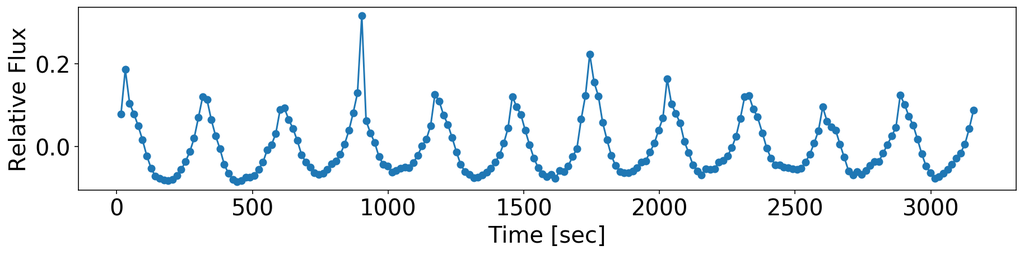

```python
import matplotlib.pyplot as pl

t=data.Time
f=data.Flux

fig,ax = pl.subplots(1,1,figsize=(15,3))
ax.plot(t,f,'o-')
ax.set(xlabel='Time [sec]',
       ylabel='Relative Flux');
```

## Finding period

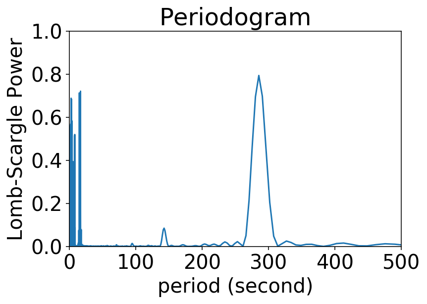

```python
from gatspy.periodic import LombScargleFast

model = LombScargleFast().fit(t, f)
periods, power = model.periodogram_auto(nyquist_factor=100)

fig, ax = pl.subplots()
ax.plot(periods, power)
ax.set(xlim=(0, 500), ylim=(0, 1),
       xlabel='period (second)',
       ylabel='Lomb-Scargle Power',
       title='Periodogram');
```

The highest peak of the periodogram corresponds to optimum period.

```python
import numpy as np

idx=np.argmax(power)
```

period in seconds

```python
p=periods[idx]
p
```

```
285.58900000000006
```

period in minutes

```python
p/60
```

```
4.7598166666666675
```

```python
#built-in optimizer
model.optimizer.period_range=(250, 300)
period = model.best_period
print("period = {0}".format(period/60))
```

```
period = 4.760856841752395
```

## Phase-folding

Let's fold the light curve and see how much the brightness varies during each period

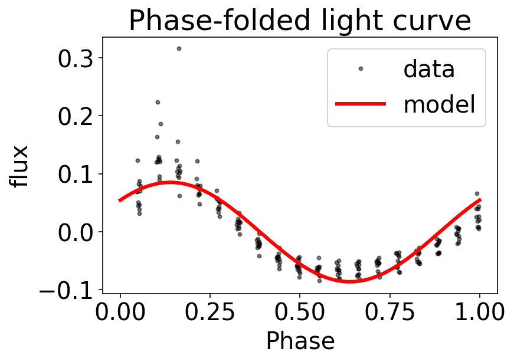

```python
phase = (t / period) % 1

# Compute best-fit template

phase_fit = np.linspace(0, 1, 1000)
f_fit = model.predict(period * phase_fit, period=period)

# Plot the phased data & model
fig, ax = pl.subplots()
ax.plot(phase, f, '.k', alpha=0.5, label='data')
ax.plot(phase_fit, f_fit, '-r', lw=3, label='model')
ax.set(xlabel='Phase',
       ylabel='flux',
      title='Phase-folded light curve');
ax.legend()
```

## scipy's optimizer

```python
def simple_sine(theta, t):
    """assumes light curve is sinusoidal"""
    a, b, c = theta
    return a * np.sin(b * t + c)

def lnlike(params, t, f):
    """model's ln likelihood"""
    m = simple_sine(params[:3], t)
    sig = params[3]
    resid = f - m
    inv_sigma2 = 1.0/(sig**2)

    return -0.5*(np.sum((resid)**2*inv_sigma2 - np.log(inv_sigma2)))


def lnprob(theta, t, f):
    """ln probability = ln like+ln prior"""
    #prior
    if np.any(theta < 0):
        return -np.inf

    #loglike
    ll = lnlike(theta, t, f)
    return ll if np.isfinite(ll) else -np.inf

nlp = lambda *args: -lnprob(*args)
```

```python
import scipy.optimize as op

init_guess = (0.1,6,0.1,0.1) #amplitude, phase, lag, uncertainty in flux
args = (phase, f)

opt = op.minimize(nlp, init_guess, args=args, method='nelder-mead')
print(opt.success)
```

```
True
```

```python
for i in opt.x:
    print ("parameter optimum: {:.4f}".format(i))
```

```
parameter optimum: 0.0874
parameter optimum: 5.7158
parameter optimum: 1.0097
parameter optimum: 0.0291
```

Plot optimized fit

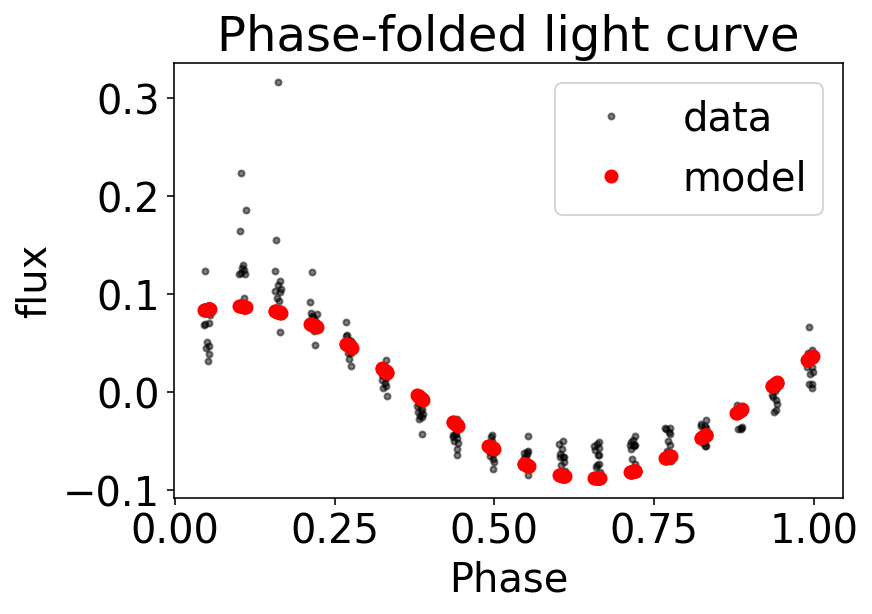

```python
# Plot the phased data & model
fig, ax = pl.subplots()

ax.plot(phase, f, '.k', alpha=0.5, label='data')
ax.plot(phase, simple_sine(opt.x[:3], phase), 'ro', lw=3, label='model')
ax.set(xlabel='Phase',
       ylabel='flux',
      title='Phase-folded light curve');
ax.legend()
```

```python
h = lambda x,a,b,c: a*np.sin(b*x+c)

p_opt, p_cov = op.curve_fit(h, phase, f, p0=init_guess[:3])
var = np.diag(p_cov)
std = np.sqrt(np.diag(p_cov)) #a.k.a. sigma

for i,j in zip(p_opt, std):
    print ("parameter optimum: {:.4f} +/- {:.4f}".format(i, j))
```

```
parameter optimum: 0.0874 +/- 0.0030
parameter optimum: 5.7158 +/- 0.1210
parameter optimum: 1.0097 +/- 0.0806
```

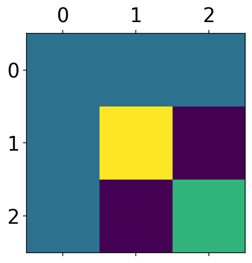

```python
pl.matshow(p_cov)
```

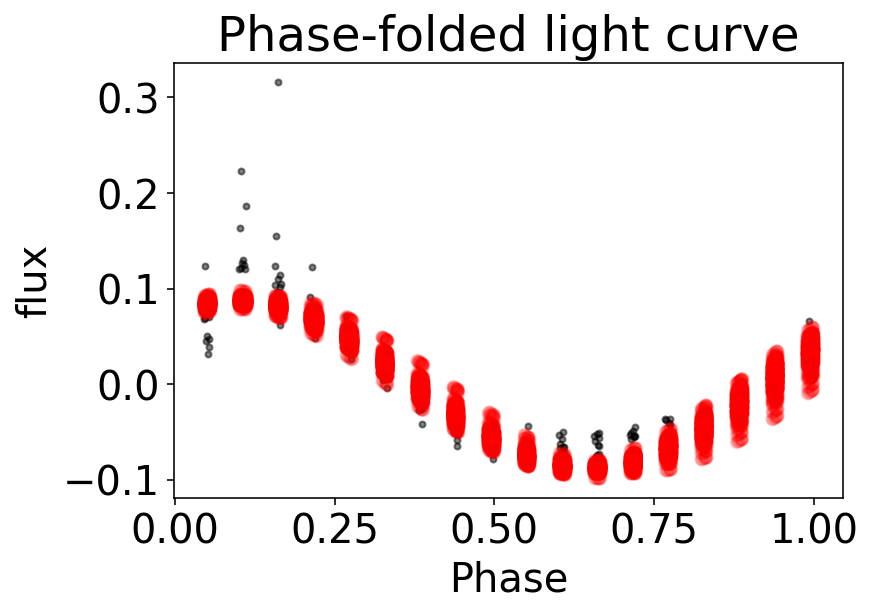

```python
# Plot the phased data & model
fig, ax = pl.subplots()

ax.plot(phase, f, '.k', alpha=0.5, label='data')
ax.plot(phase, h(phase, *p_opt), 'ro', lw=3, label='model')

for i in range(100):
    theta = p_opt + np.random.randn(p_opt.size) * std
    pl.plot(phase, h(phase, *theta),'ro', lw=3, alpha=0.1)

ax.set(xlabel='Phase',
       ylabel='flux',
      title='Phase-folded light curve');
#ax.legend()
```

## MCMC

Use markov chain monte carlo with ensemble sampler to explore parameter space and quantify uncertainty.

```python
from emcee import EnsembleSampler
from emcee.utils import sample_ball
from tqdm import tqdm

# initial = opt.x

ndim = len(init_guess)
nwalkers = 8 * ndim
nsteps1 = 500
nsteps2 = 3000

sampler = EnsembleSampler(nwalkers, ndim, lnprob, args=args, threads=1)
pos0 = sample_ball(init_guess, [1e-1]*ndim, nwalkers)

width = 30
print("\nstage 1")
for pos,_,_ in tqdm(sampler.sample(pos0, iterations=nsteps1)):
    pass
```

```
0it [00:00, ?it/s]/home/jp/miniconda3/envs/py3/lib/python3.7/site-packages/emcee/moves/red_blue.py:99: RuntimeWarning: invalid value encountered in double_scalars
  lnpdiff = f + nlp - state.log_prob[j]
4it [00:00, 36.21it/s]
```

```
stage 1
```

```
500it [00:14, 34.02it/s]
```

```python
print("\nstage 2")
idx = np.argmax(sampler.lnprobability)
best = sampler.flatchain[idx]
pos0 = sample_ball(best, [1e-5]*ndim, nwalkers)
sampler.reset()

for pos,_,_ in tqdm(sampler.sample(pos0, iterations=nsteps2)):
    pass
```

```
2it [00:00, 14.81it/s]
```

```
stage 2
```

```
3000it [01:32, 32.56it/s]
```

```python
chain = sampler.chain
labels = ['${}$'.format(i) for i in r'A,\theta,\phi,\sigma'.split(',')]
```

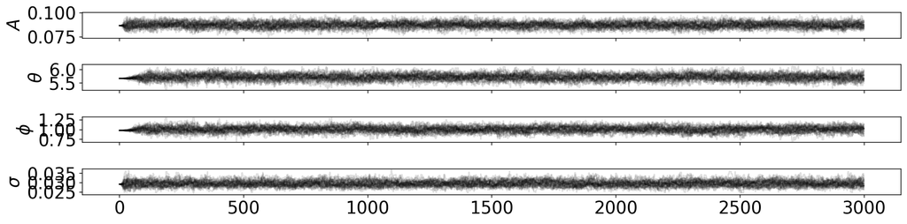

```python
fig, axs = pl.subplots(ndim, 1, figsize=(15,ndim), sharex=True)
[axs.flat[i].plot(c, drawstyle='steps', color='k', alpha=4./nwalkers) for i,c in enumerate(chain.T)]
[ax.set_ylabel(labels[i], fontsize=20) for i,ax in enumerate(axs)]
fig.tight_layout()
```

```python
chain.shape
```

```
(32, 3000, 4)
```

```python
#flatten the chain
fc = np.reshape(chain,(-1,ndim))
```

Measure autocorrelation needed to ensure independent sampling.

```python
from acor import acor

taus = []
for i in range(ndim):
    j = fc[:,i]
    tau,_,_ =acor(j)
    tau = int(round(tau))
    taus.append(tau)
    print('tau={}\t ndata={}'.format(tau,len(j[::tau])))
```

```
tau=47	 ndata=2043
tau=55	 ndata=1746
tau=45	 ndata=2134
tau=38	 ndata=2527
```

## joint and marginal distributions

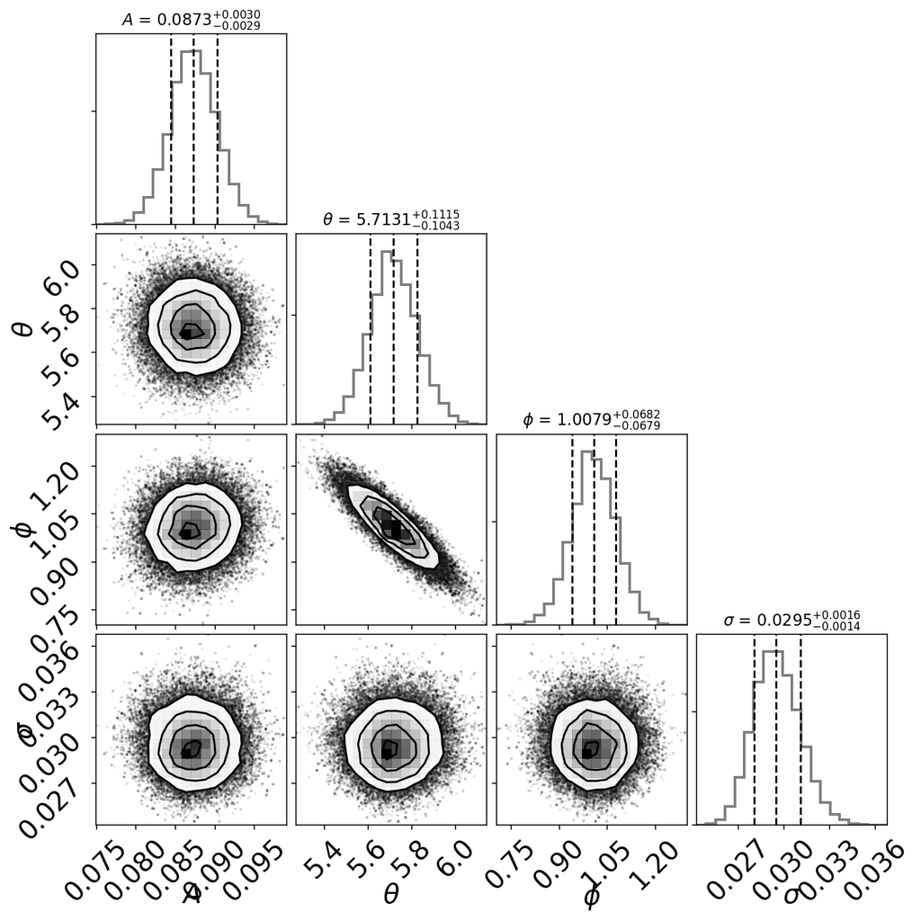

```python
from corner import corner

hist_kwargs = dict(lw=2, alpha=0.5)
title_kwargs = dict(fontdict=dict(fontsize=12))

fig = pl.figure(figsize=(8,8))

corner(fc, labels=labels, #truths=truths,
       hist_kwargs=hist_kwargs,
       title_kwargs=title_kwargs,
       show_titles=True,
       quantiles=[0.16,0.5,0.84],
       title_fmt='.4f');
#     fig.tight_layout()
```

```python
df=pd.DataFrame(fc)
df.columns = ['A','theta','phi','sigma']
```

```python
df.describe()
```

|  | A | theta | phi | sigma |
| --- | --- | --- | --- | --- |
| count | 96000.000000 | 96000.000000 | 96000.000000 | 96000.000000 |
| mean | 0.087307 | 5.716060 | 1.008236 | 0.029550 |
| std | 0.002961 | 0.109834 | 0.069403 | 0.001527 |
| min | 0.074923 | 5.270794 | 0.703959 | 0.024256 |
| 25% | 0.085313 | 5.644638 | 0.963196 | 0.028471 |
| 50% | 0.087269 | 5.713094 | 1.007949 | 0.029464 |
| 75% | 0.089271 | 5.788691 | 1.054815 | 0.030548 |
| max | 0.099071 | 6.141251 | 1.298558 | 0.036770 |

```python
def get_stats(sample,tol=4):
    '''
    return 50th, 16th, and 84th percentiles
    (median & 1 sigma limits) of a given sample
    '''
    l,m,r = np.percentile(sample,[16,50,84])

    return m, m-l, r-m
```

```python
vals, uncs = [], []

for i in range(ndim):
    j=fc[:,i][taus[i]]
    d=get_stats(j)
    vals.append(d[0])
    uncs.append((d[1],d[2]))
    print('{:.6f} +{:.6f} -{:.6f}'.format((d[0]),d[1],d[2]))
```

```
0.084231 +0.000000 -0.000000
5.776425 +0.000000 -0.000000
0.980014 +0.000000 -0.000000
0.029066 +0.000000 -0.000000
```

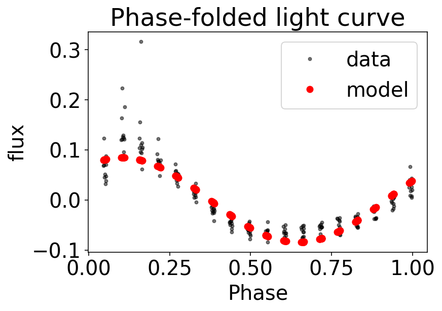

```python
# Plot the phased data & model
fig, ax = pl.subplots()

ax.plot(phase, f, '.k', alpha=0.5, label='data')
ax.plot(phase, h(phase, *vals[:3]), 'ro', lw=3, label='model')

ax.set(xlabel='Phase',
       ylabel='flux',
      title='Phase-folded light curve');
ax.legend()
```